# NoteBook MDS - ML Imagenes

##### Realizado por:

- **Nestor Jardany Serrano Rojas**, [GitHub](https://github.com/jardanys/Anomalia_Imputacion_Imagenes)

## MDS

Se seleccionan 6 ciudades al azar de la página [enlace](http://es.distancias.himmera.com/distancia_entre_ciudades-colombia_mapas_carreteras/) y se comparan las distancias por carretera y en línea recta (avión).

El objetivo es determinar la mejor estimación de las distancias geoespacial dadas las distancias en carretera y linea recta de las seis ciudades.

## MDS - Distancias en carretera

De la página mencionada se obtienen las distancias y matriz de distancias en carretera de siguientes ciudades:

- Bogotá
- Cartagena
- Villeta
- Barbosa
- Yopal
- San Gíl

```r
ciudades <- c("Bogotá", "Cartagena", "Villeta", "Barbosa", "Yopal", "San Gil")
D <- matrix(0,length(ciudades),length(ciudades))
D[1, 2:6] <- c(1060, 90, 185, 356, 300)
D[2, 3:6] <- c(994, 860, 1133, 751)
D[3, 4:6] <- c(260, 435, 375)
D[4, 5:6] <- c(275, 115)
D[5, 5:6] <- c(381)
D <- D+t(D)
colnames(D) <- ciudades
rownames(D) <- ciudades
```

### Multi-Dimensional Scaling Carretera

Se obtiene la estimación multidimensional esclada de la matriz de distancias de las 6 ciudades mencionadas. Se guarda en una matriz X con una posición en el eje “X” y en el eje “Y”.

```r
n <- length(ciudades)
uno <- matrix(1,n,1)
I <- diag(n)
J <- I - (uno%*%t(uno))/n
B <- - J%*%D^2%*%J/2
eigen.B <- eigen(B, symmetric=TRUE)
E <- eigen.B$vectors[,1:2]
L <- matrix(0,2,2)
diag(L) <- eigen.B$values[1:2]
X <- E%*%sqrt(L)
rownames(X) <- ciudades
mm <- max(abs(X))
data <- as.data.frame(X)
```

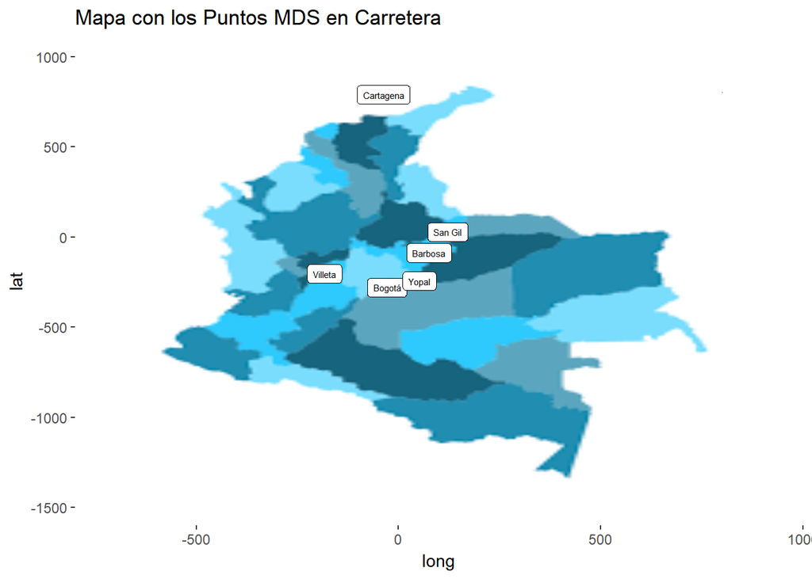

```r
colombia <- png::readPNG("colombia.png")
ggplot(data, aes(800,800)) + geom_line_with_image(colombia) +
  geom_point(aes(V2,-V1)) + xlim(-800,1000) + ylim(-1600,1100) +
  geom_label(aes(V2,-V1,label=rownames(data)), size=2) + xlab("long") + ylab("lat") +
  ggtitle("Mapa con los Puntos MDS en Carretera")
```

## MDS - Distancias en linea (Aeria)

- Bogotá
- Cartagena
- Villeta
- Barbosa
- Yopal
- San Gíl

```r
ciudades <- c("Bogotá", "Cartagena", "Villeta", "Barbosa", "Yopal", "San Gil")
D <- matrix(0,length(ciudades),length(ciudades))
D[1, 2:6] <- c(650, 55, 145, 198, 230)
D[2, 3:6] <- c(609, 536, 635, 515)
D[3, 4:6] <- c(139, 232, 226)
D[4, 5:6] <- c(149, 87)
D[5, 5:6] <- c(156)
D <- D+t(D)
colnames(D) <- ciudades
rownames(D) <- ciudades
```

Se obtiene la estimación multidimensional esclada de la matriz de distancias de las 6 ciudades mencionadas. Se guarda en una matriz X con una posición en el eje “X” y en el eje “Y”.

```r
n <- length(ciudades)
uno <- matrix(1,n,1)
I <- diag(n)
J <- I - (uno%*%t(uno))/n
B <- - J%*%D^2%*%J/2
eigen.B <- eigen(B, symmetric=TRUE)
E <- eigen.B$vectors[,1:2]
L <- matrix(0,2,2)
diag(L) <- eigen.B$values[1:2]
X <- E%*%sqrt(L)
rownames(X) <- ciudades
mm <- max(abs(X))
data <- as.data.frame(X)
```

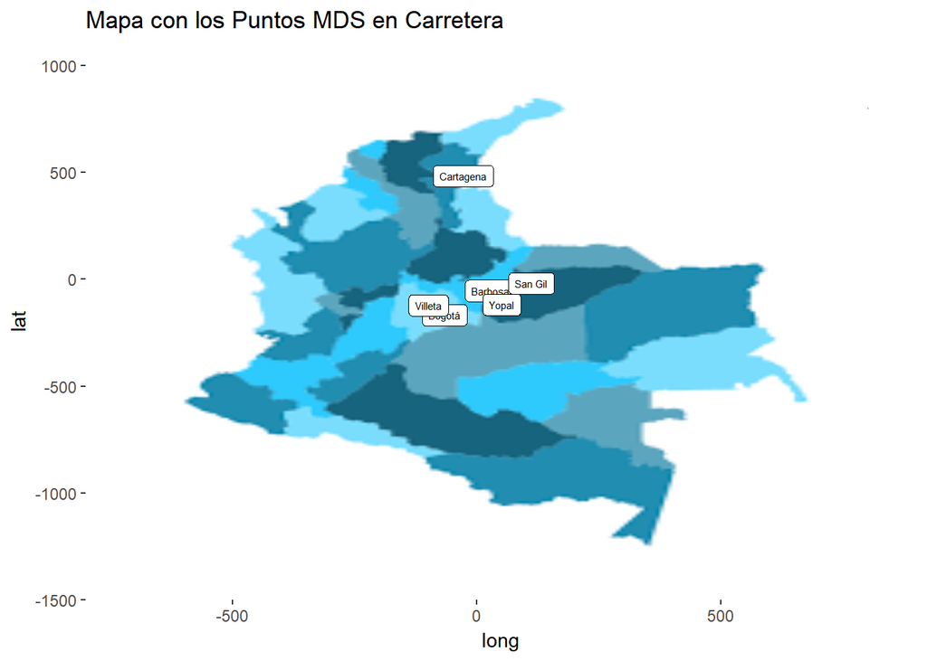

```r
colombia <- png::readPNG("colombia.png")
ggplot(data, aes(800,800)) + geom_line_with_image(colombia) +
  geom_point(aes(V2,-V1)) + xlim(-800,900) + ylim(-1500,1100) +
  geom_label(aes(V2,-V1,label=rownames(data)), size=2) + xlab("long") + ylab("lat") +
  ggtitle("Mapa con los Puntos MDS en Carretera")
```

2018-04 Nestor Jardany Serrano Rojas

Copyright © All rights reserved.